# Modeling Tides

The file `hawaii.csv` contains hour-by-hour measurements of water level in Pearl Harbor, Hawaii, over approximately 4 days.

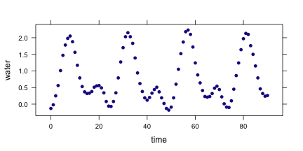

```r
library(mosaic, quietly = TRUE)
trellis.par.set(theme = col.mosaic())
tides = fetchData("hawaii.csv")
xyplot(water ~ time, data = tides)
```

How to model these data? They are repetitive, which suggests a sine-wave model. We need to know the period, amplitude, phase, and offset. Looking at the graph suggests a period of about 24 hours, as seems sensible.

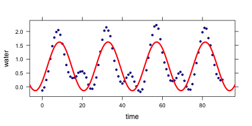

```r
f0 = fitModel(water ~ A + B * sin(2 * pi * (time - T0)/P), data = tides,
    start = list(P = 24))
xyplot(water ~ time, data = tides, pch = 20)
plotFun(f0(time) ~ time, add = TRUE, lwd = 3, col = "red")
```

Here, `T0` is the phase of the sine function.

Another way to address the phase issue is to add a cosine of the same period.  
Fitting that sort of model, and comparing to the time-shift parameterization shows that they are effectively the same.

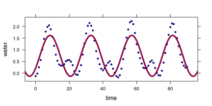

```r
f1 = fitModel(water ~ A + B * sin(2 * pi * time/P) + C * cos(2 *
    pi * time/P), data = tides, start = list(P = 24))
xyplot(water ~ time, data = tides, pch = 20)
plotFun(f1(time) ~ time, add = TRUE, lwd = 4)
plotFun(f0(time) ~ time, add = TRUE, col = "red")
```

According to the model, what's the period?

That's a pretty rough model. Perhaps that's because there are often two tides per day. So there's something going on with a period of about 12 hours. A new model:

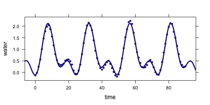

```r
f2 = fitModel(water ~ A + B * sin(2 * pi * time/P1) + C * cos(2 *
    pi * time/P1) + D * sin(2 * pi * time/P2) + E * cos(2 * pi * time/P2), data = tides,
    start = list(P1 = 24, P2 = 12))
xyplot(water ~ time, data = tides, pch = 20)
plotFun(f2(time) ~ time, add = TRUE, lwd = 3)
```

Much better!

## Questions

1. What's the relationship between the two periods?
2. Do you get a much better model with three or more periods? What should those new periods be?
3. The model is quite good, yet the fundamental period is not 24 hours. Why not?

## Resources

- A source for minute-by-minute data from [NOAA](http://tidesandcurrents.noaa.gov/tsunami/#)
- A bit of [nomenclature](http://oceanservice.noaa.gov/education/kits/tides/media/supp_tide07a.html)